# Objective A

Slyterin

# 1 Design of the study

## 1.1 Aims

To investigate Bayesian methods for left-censored data and compare them against existing frequentist methods (substitution and ROS) using simulation studies.

The comparison is to be carried out in a range of scenarios:

- Single-element model and two-element model.
- For each model, compare across different combinations of sample size, censoring proportion, and single/multiple reporting limits.

## 1.2 Data-generating mechanisms

**Single-element model**

We consider 40 data-generating mechanisms for single-element model. For each, data are simulated with $n_\text{obs}$ concentrations and $p_\text{censoring}$ level of censoring. Let $Y_i \in \mathbb R_+$ denote the concentration value, we first generate complete (not censored) data using $\ln Y_i \sim \mathcal{N}(0.5, 1^2)$.

Based on the complete data, we decide on the reporting limits using another variable “is_censored”. For single-reporting-limit scenario, the reporting limit and “is_censored” is determined by the $p_\text{censoring}$ quantile of the concentration. For multiple-reporting-limit we used the method described in the paper to decide the reporting limits and “is_censored”. The sampled dataset thus contains two columns:

- concentration (numeric): observed value / reporting limit;
- is_censored (logical).

The 40 data-generating mechanisms differ in:

1. sample size ($n_{\text{obs}} \in \{25, 75, 125, 175, 225\}$);
2. censoring proportion ($p_{\text{censoring}} \in \{0.2, 0.4, 0.6, 0.8\}$), and;
3. category of reporting limits: single reporting limit or multiple reporting limit.

**Two-element model**

We also consider 40 data-generating mechanisms for two-element model. It’s similar to one-element model, except that $Y_i \in \mathbb R^2_+$ and $(Y_{i1}, Y_{i2})^T \sim \mathcal N_2 \left ((0.5, 0.5)^T, \begin{pmatrix}1 & 0.5 \\ 0.5 & 1 \end{pmatrix}\right )$. The censoring of $Y_{i1}, Y_{i2}$ was done separately and independently.

Data are simulated using R functions:

- $\texttt{rnorm}$ for single element and
- $\texttt{rmvnorm}$ for two elements.

The input seed is “1”.

## 1.3 Estimands

**Single-element model**

Our estimands for single-element model include geometric mean (GM), geometric standard deviation (GSD), arithmetic mean (AM) and 95% quantile (Q95) for the concentration.

The true values of the estimands are as below shown in the table:

```r
mu <- 0.5; sd <- 1
# GM
gm <- exp(mu)
# GSD
gsd <- exp(sd)
# AM
am <- exp(mu + sd^2 / 2)
# Q95
q95 <- qlnorm(0.95, meanlog = mu, sdlog = sd)
# True values
true_vals1 <- data.frame(param = c("GM", "GSD", "AM", "Q95"),
                        true = c(gm, gsd, am, q95))
print(true_vals1)
```

```
##   param     true
## 1    GM 1.648721
## 2   GSD 2.718282
## 3    AM 2.718282
## 4   Q95 8.540791
```

**Two-element model**

The estimands for two-element model also include geometric mean, geometric standard deviation, arithmetic mean and 95% quantile but for the sum of the two concentrations.

We only have true values of AM for the sum of the two concentrations, since the sum of two lognormals doesn’t entail closed form density. AM is computed as the sum of AMs of each concentration. The detailed explanation is in the appendix.

However, we can perform Monte Carlo simulation to find approximate true values of GM, GSD and Q95 by simulating from the true parameters of $(Y_1, Y_2)^T$.

```r
mu1 <- 0.5; mu2 <- 0.5
sd1 <- 1; sd2 <- 1
rho <- 0.5
# AM of Y1 + Y2
am_Y1plusY2 <- exp(mu1 + sd1^2 / 2) + exp(mu2 + sd2^2 / 2) # 5.436564

# Monte Carlo
set.seed(222)
n.mc <- 5000
n.obs <- 1000
mean <- c(mu1, mu2)
S <- matrix(c(sd1^2, rho * sd1 * sd2, rho * sd1 * sd2, sd2^2), nrow = 2)
estimates <- matrix(nrow = n.mc, ncol = 4,
                    dimnames = list(NULL, c('gm_hat', 'gsd_hat', 'am_hat', 'q95_hat')))
for (iter in 1:n.mc){
  logY <- rmvnorm(n.obs, mean = mean, sigma = S)
  Y <- exp(logY)
  Ysum <- rowSums(Y)
  logYsum <- log(Ysum)
  estimates[iter, 'gm_hat'] <- exp(mean(logYsum))
  estimates[iter, 'gsd_hat'] <- exp(sd(logYsum))
  estimates[iter, 'am_hat']  <- mean(Ysum)
  estimates[iter, 'q95_hat']  <- quantile(Ysum, 0.95)
}


# "True" values
true_vals2 <- data.frame(param = c("GM", "GSD", "AM", "Q95"),
                        true = colMeans(estimates))
print(true_vals2)# The approximated am is very close to the true one
```

```
##         param      true
## gm_hat     GM  3.693765
## gsd_hat   GSD  2.406293
## am_hat     AM  5.437204
## q95_hat   Q95 15.652533
```

## 1.4 Methods

Each simulated dataset is analyzed using both Bayesian and Frequentist methods:

- Bayesian methods: Gibbs and Metropolis
- Frequentist: substitution and ROS

## 1.5 Performance measures

We compare the Bayesian methods and Frequentist methods using two performance measures: relative bias and relative RMSE. Specifically for the Bayesian methods, we also assess convergence.

For simplicity, we decided using 100 Monte Carlo replications to obtain 100-observation sample estimates of each estimands $(\hat\theta_i, i = 1, 2, \dots, 100)$.

# 2 Exploratory analysis of results

## 2.1 Single-element model

**About the methods used**

We applied all suggested methods across the 40 data-generating mechanisms, including Metropolis and Gibbs samplers for the Bayesian approach, and ROS, substitution (using fixed factors of $\frac12$ and $1/\sqrt{2} \approx 0.7$, as well as beta-substitution (using random factors drawn from a $\beta(2, 2)$ distribution) for the Frequentist approach.

**EDA of results from selected data-generating mechanism.**

Here present the results for 4 data-generating mechanisms:

1. sample size = 25, censoring proportion = 0.2, single reporting limit
2. sample size = 25, censoring proportion = 0.2, multiple reporting limits
3. sample size = 225, censoring proportion = 0.4, single reporting limit
4. sample size = 225, censoring proportion = 0.4, multiple reporting limits

From the graphs, we observe the following overall patterns:

- Bayesian methods generally provide good estimates for the arithmetic mean (AM), geometric mean (GM), and geometric standard deviation (GSD), with values close to the true ones. However, they tend to underestimate the 95% quantile across all scenarios.
- Frequentist methods are less consistent than Bayesian methods in estimating AM and GM, especially with higher censoring. They often underestimate AM and overestimate GM as censoring increases. Nevertheless, their quantile estimates are typically close to the true values, although there is a fair amount of variability in the estimates.
- Different methods within the Bayesian approach produce similar results, as do the various Frequentist methods.

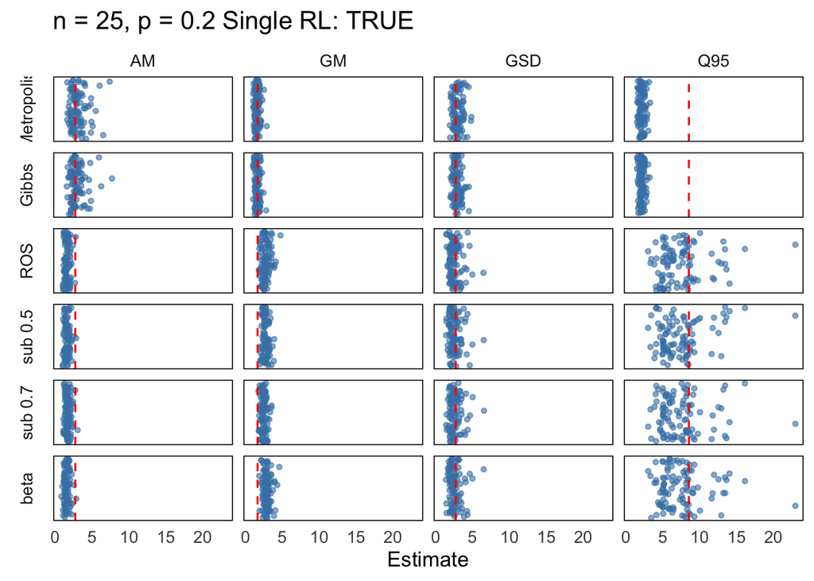

```r
# Load the estimates of all data and all methods
estimands1 <- read.csv('single_element_estimands.csv') %>%
  left_join(true_vals1, by = "param")

estimands1$param <- factor(estimands1$param,
                          levels = c('GM', 'GSD', 'AM', 'Q95'))

estimands1$method <- factor(estimands1$method,
                           levels = c('Metropolis',
                                      'Gibbs',
                                      'ROS',
                                      'substition with coef 0.5',
                                      'substition with coef 0.7',
                                      'beta-substitution'))

levels(estimands1$method) <- c('Metropolis',
                              'Gibbs',
                              'ROS',
                              'sub 0.5',
                              'sub 0.7',
                              'beta')

# Load the grid list to get data-generating mechanism of each row of the results
grid <- expand.grid(
  n = seq(25, 250, by = 50),
  p = seq(0.2, 0.8, by = 0.2),
  single.rl = c(TRUE, FALSE),
  stringsAsFactors = FALSE
)

# Plot for specific data-generating mechanism
plot_by_dg <- function(estimands, idx){
  dg <- grid[idx, ]
  df <- estimands %>%
    filter(grid_idx == idx) %>%
    dplyr::select(method, param, estimate)

  plot <- ggplot(df, aes(x = estimate, y = 0)) +
      geom_jitter(height = 0.1, alpha = 0.6, color = "steelblue", size = 1.2) +
      geom_vline(data = true_vals1, aes(xintercept = true),
                 color = "red", linetype = "dashed", linewidth = 0.6) +
      facet_grid(rows = vars(method), cols = vars(param), switch = "y") +
      theme_minimal(base_size = 13) +
      theme(
        panel.grid = element_blank(),
        panel.border = element_rect(color = "black", fill = NA),
        strip.placement = "outside",
        strip.background = element_blank(),
        axis.title.y = element_blank(),
        axis.text.y = element_blank(),
        axis.ticks.y = element_blank()
      ) +
      labs(title = paste('n = ', dg$n,
                         ', p = ', dg$p,
                         ' Single RL: ', dg$single.rl,
                         sep = ''),
           x = "Estimate")
  return(plot)
}

plot_by_dg(estimands1, 1)
```

For a small sample size (n = 25), both methods provide reasonable estimates for AM, GM, and GSD (excluding the quantile), especially when the censoring proportion is low and there is only one reporting limit. The Bayesian estimates are generally closer to the true values, though there is greater variability in the AM estimates. For GSD, both methods are centered around the true values, but the Bayesian estimates are more concentrated.

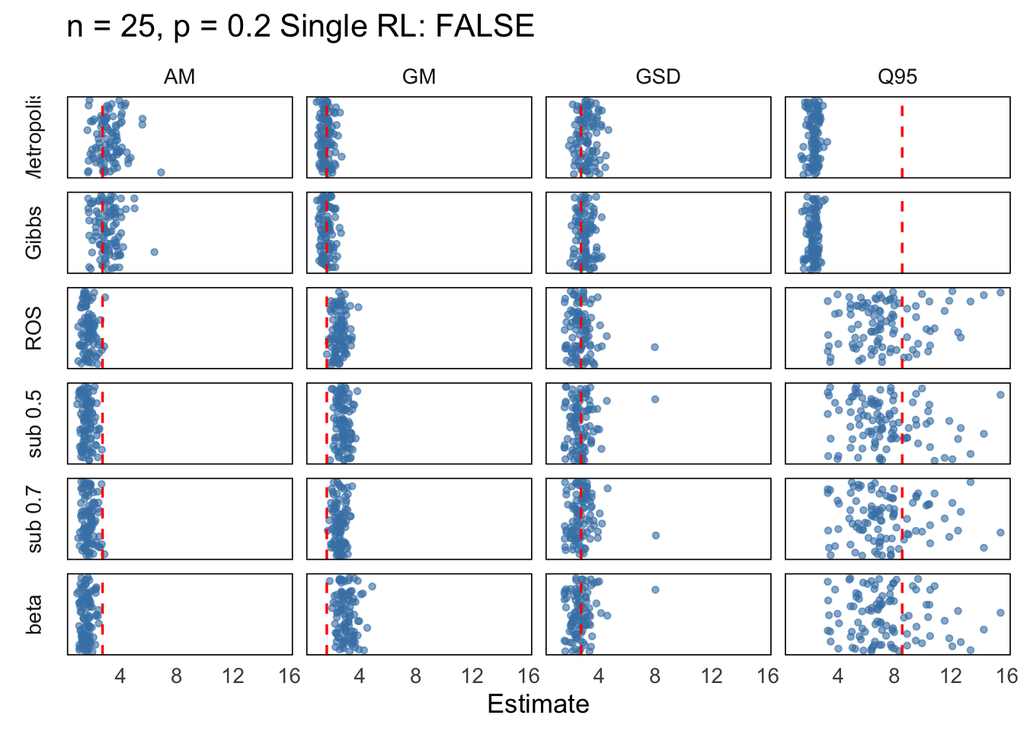

```r
plot_by_dg(estimands1, 21)
```

With the same sample size and censoring proportion but multiple reporting limits, we observe a larger spread in all estimates. The Bayesian quantile estimates are even further from the true values. For GSD, the estimates remain centered around the true values. However, the Frequentist method tends to estimate the GM as larger than the true value and the AM as smaller.

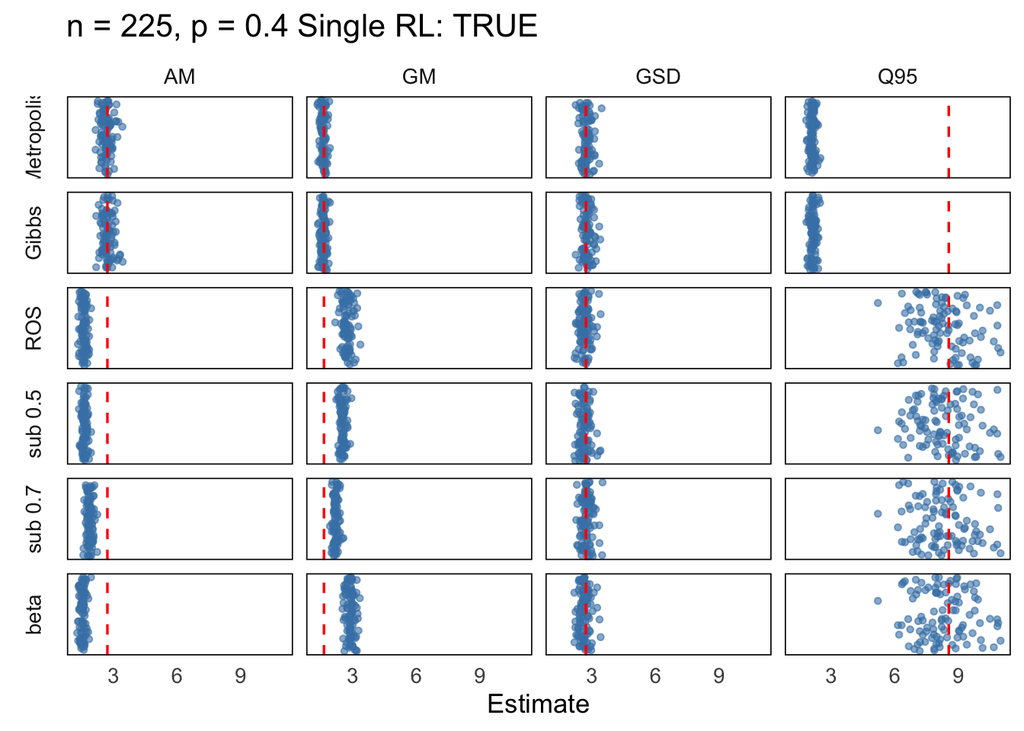

```r
plot_by_dg(estimands1, 10)
```

When the sample size is large (n = 225) and the censoring proportion increases to 0.4, with a single reporting limit, we observe more concentrated estimates from the Bayesian methods for AM, GM, and GSD. However, the quantile estimates are significantly left of the true values. The Frequentist methods show a more severe underestimation of AM and overestimation of GM. For GSD, both methods still perform well. The Frequentist methods also provide fairly accurate quantile estimates, despite a larger spread.

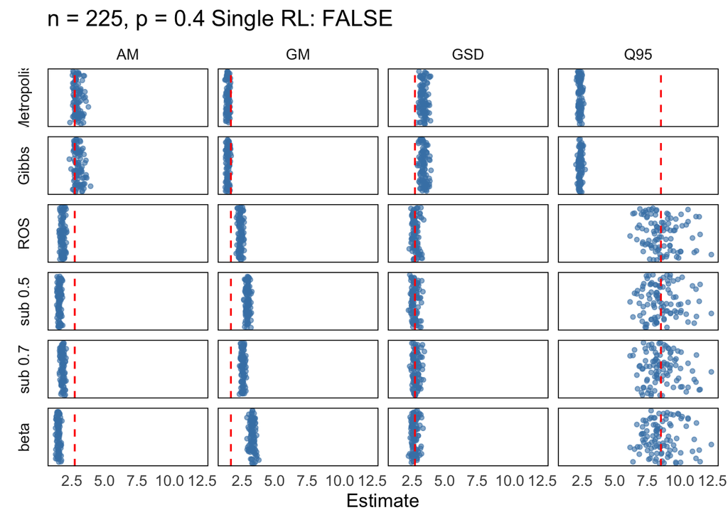

```r
plot_by_dg(estimands1, 30)
```

When the reporting limits are multiple, and the sample size and censoring proportion remain the same, we don’t observe much difference in the spread of estimates across the methods. An interesting finding is that Bayesian estimates for GSD tend to overestimate, while AM is slightly right of the true values and GM is slightly left of the true values. For the Frequentist method, quantile estimates remain good, though they are less centered around the true values, shifting more to the right. It seems that Bayesian and Frequentist methods exhibit opposite patterns as the scenarios change.

**General checking of convergence by Gelman-Rubin $\hat r$ point estimates**

We perform a rough check of the convergence for each Bayesian method using the Gelman-Rubin $\hat r$ point estimates. For the Gibbs sampler, we ran 2 chains, each with 9,000 iterations, of which 4000 were burn-in. For the Metropolis method, we ran 3 chains, each with 10,000 iterations, of which 5000 were burn-in. The Gelman-Rubin $\hat r$ , effective sample size, and autocorrelation were computed and recorded. In the following, we show the Gelman-Rubin $\hat r$ histogram across all runs (4000 in total, with 40 data-generating mechanisms and 100 Monte Carlo iterations per mechanism). The red vertical line in the histograms represents the threshold of Gelman-Rubin $\hat r = 1.1$. Most runs fall below this threshold, indicating good convergence for both Bayesian methods. The Gibbs sampler shows particularly strong convergence.

Further details on the convergence check for the Metropolis method can be found in the appendix.

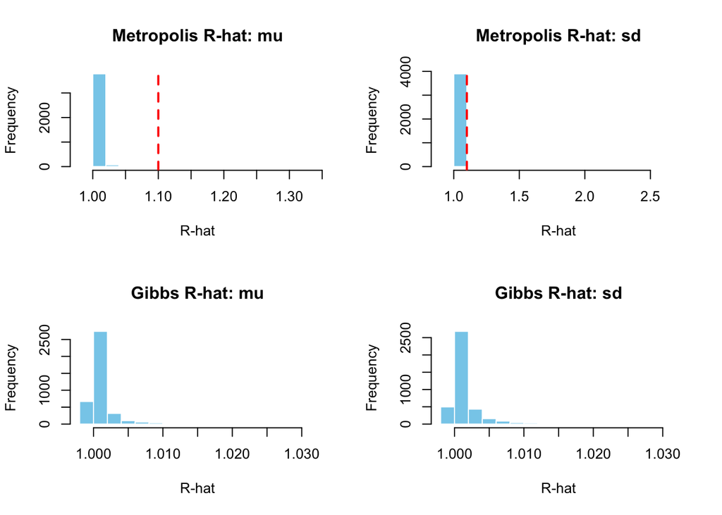

```r
# Load rhats
metro_rhat1 <- readRDS('single_element_metropolis_rhat.rds')
gibbs_rhat1 <- readRDS('single_element_gibbs_rhat.rds')

# Set rhat threshold
rhat_threshold <- 1.1

par(mfrow = c(2, 2))
# Metropolis
# Plot
# mu
hist(metro_rhat1[1, ], breaks = 20, col = "skyblue", border = "white",
               main = "Metropolis R-hat: mu", xlab = "R-hat")
abline(v = rhat_threshold, col = "red", lwd = 2, lty = 2)
# sd
hist(metro_rhat1[2, ], breaks = 20, col = "skyblue", border = "white",
               main = "Metropolis R-hat: sd", xlab = "R-hat")
abline(v = rhat_threshold, col = "red", lwd = 2, lty = 2)

# Gibbs
# Plot
# mu
hist(gibbs_rhat1[1, ], breaks = 20, col = "skyblue", border = "white",
               main = "Gibbs R-hat: mu", xlab = "R-hat")
abline(v = rhat_threshold, col = "red", lwd = 2, lty = 2)
# sd
hist(gibbs_rhat1[2, ], breaks = 20, col = "skyblue", border = "white",
               main = "Gibbs R-hat: sd", xlab = "R-hat")
abline(v = rhat_threshold, col = "red", lwd = 2, lty = 2)
```

## 2.2 Two-element model

**About the methods used**

For the two-element model, we used only the Gibbs sampler for Bayesian inference. The Metropolis algorithm was not used due to its high computational cost when evaluating the bivariate likelihood. While approximation methods could reduce this burden, the parameter-updating scheme we adopted makes them prone to numerical instability—often leading to a non–positive-definite posterior covariance matrix, which causes failure in predicting $\hat Y$.

As a result, we implemented bivariate Gibbs sampling across all data-generating mechanisms.

The Frequentist methods used were the same as in the single-element model. However, one limitation is that the two elements were imputed independently in all Frequentist approaches, which is likely problematic given the dependency structure between them.

**EDA of the results**

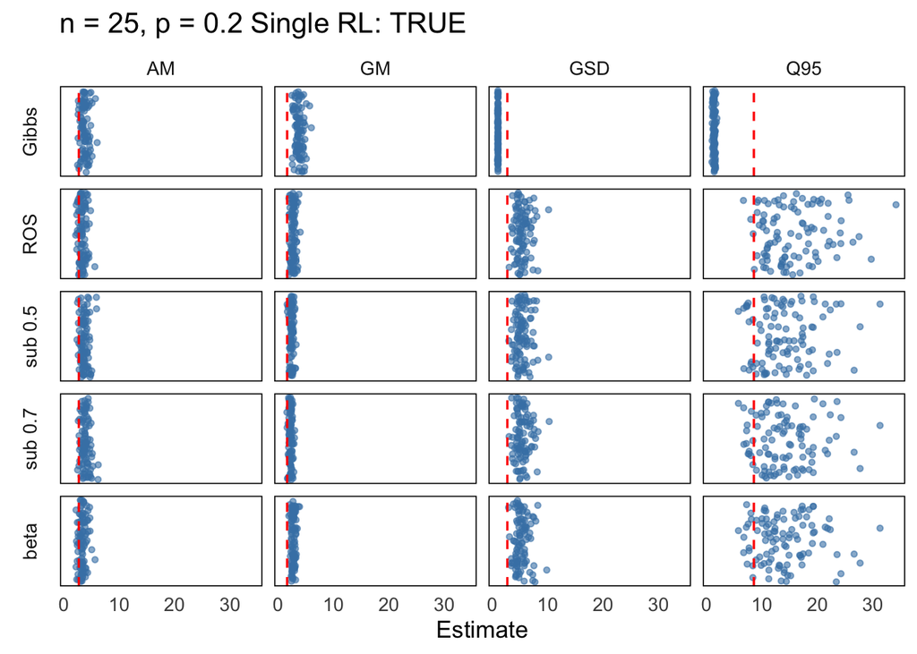

```r
estimands2 <- read.csv('two_element_estimands.csv') %>%
  left_join(true_vals2, by = "param")

estimands2$param <- factor(estimands2$param,
                          levels = c('GM', 'GSD', 'AM', 'Q95'))

estimands2$method <- factor(estimands2$method,
                           levels = c("Gibbs",
                                      "ROS",
                                      "substitution with coef: 0.5, 0.5",
                                      "substitution with coef: 0.7, 0.7",
                                      "beta-substitution"))

levels(estimands2$method) <- c('Gibbs',
                              'ROS',
                              'sub 0.5',
                              'sub 0.7',
                              'beta')

# Load the grid list to get data-generating mechanism of each row of the results
grid <- expand.grid(
  n = seq(25, 250, by = 50),
  p = seq(0.2, 0.8, by = 0.2),
  single.rl = c(TRUE, FALSE),
  stringsAsFactors = FALSE
)
plot_by_dg(estimands2, 1)
```

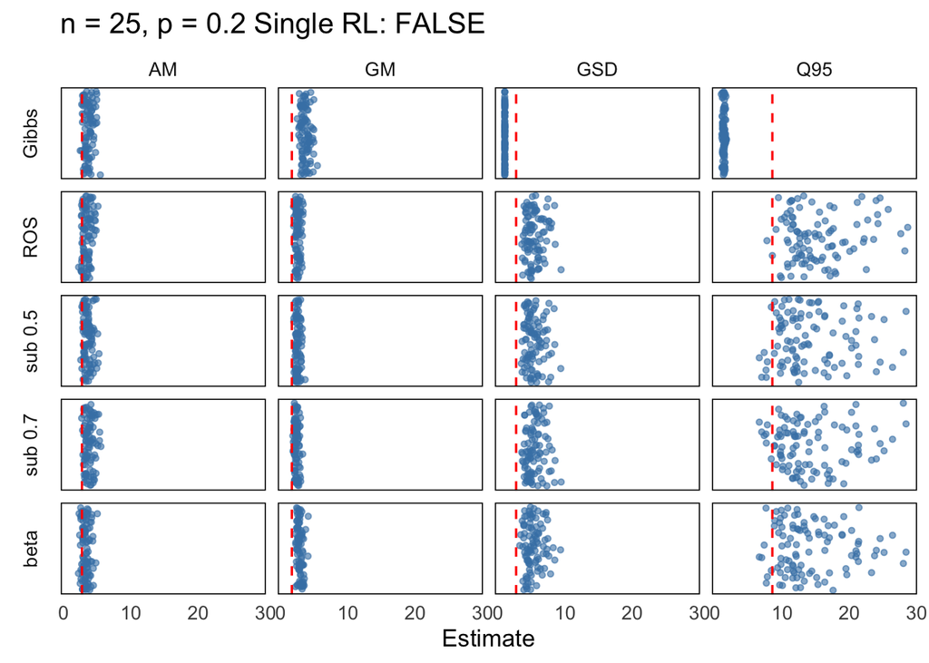

```r
plot_by_dg(estimands2, 21)
```

With the same sample size and censoring level, but with multiple reporting limits, we observe a similar pattern as before. The main difference is a slightly larger spread in the GSD and quantile estimates from the Frequentist methods.

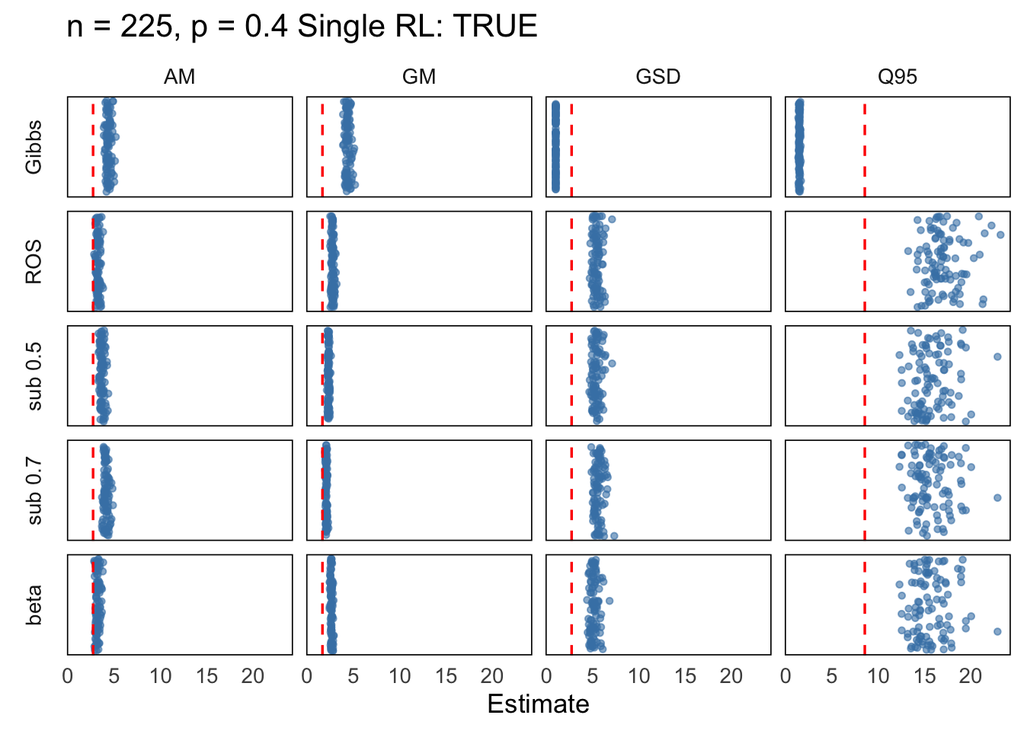

```r
plot_by_dg(estimands2, 10)
```

When the sample size (n = 225) is much larger and the censoring level slightly higher (p = 0.4), the Gibbs sampler’s bias increases noticeably in the same direction as before—overestimating AM and GM, while underestimating GSD and the quantile. In contrast, the Frequentist methods still perform reasonably well for AM and GM, but their estimates for GSD and the quantile are substantially off, with both being strongly overestimated.

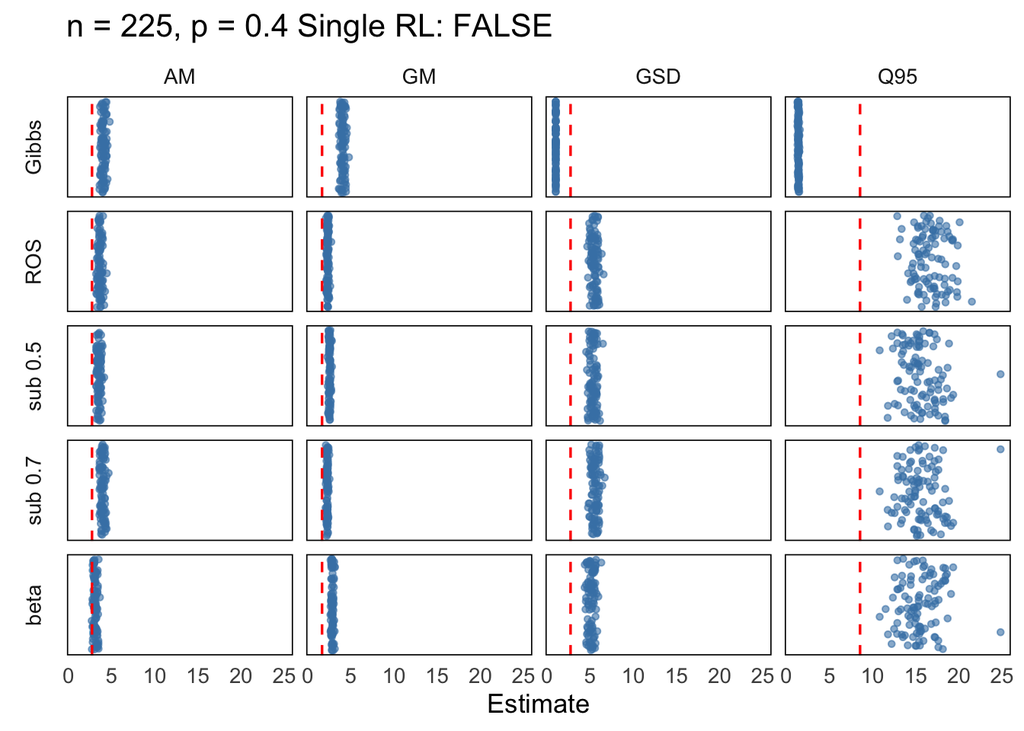

```r
plot_by_dg(estimands2, 30)
```

Surprisingly, the scenarios with multiple versus single reporting limits show little difference in estimation performance when the sample size and censoring level are held constant. This suggests that the censoring level is the dominant factor influencing the results.

**Convergence of Gibbs sampler**

The Gibbs sampler also shows good convergence for the two-element model. As shown in the graph below, all Gelman-Rubin $\hat r$ values are close to 1 across all runs, indicating convergence. We also examined the effective sample size (ESS) and autocorrelation (ACF), both of which are satisfactory—the autocorrelations are close to 0 in all cases. While ESS and ACF are not displayed here, their values are provided in the convergence statistics spreadsheet.

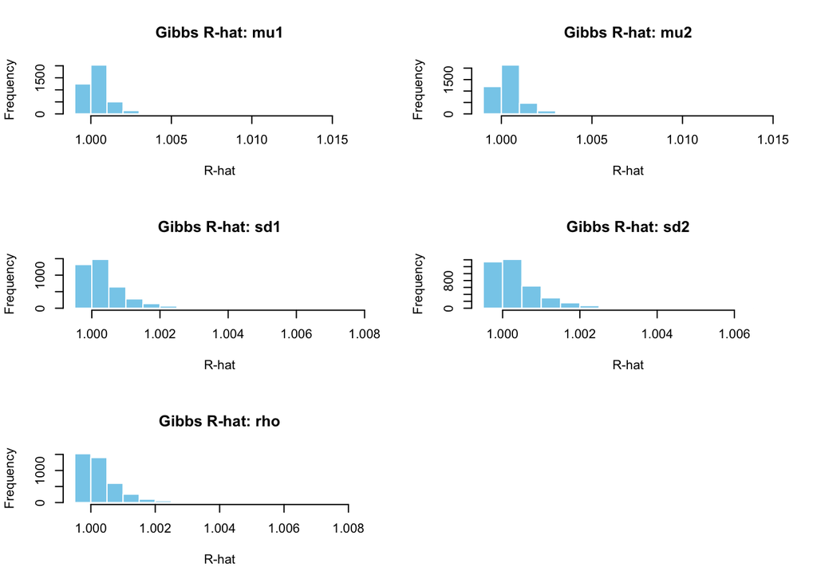

```r
# Load rhats
conv_stats2 <- read.csv('two_element_gibbs_convergence.csv')

par(mfrow = c(3, 2))

# Gibbs
# mu1
conv_stats2 %>%
  filter(param == 'mu1') %>%
  dplyr::select(rhat.Point.est.) %>%
  unlist() %>%
  hist(breaks = 20, col = "skyblue", border = "white",
               main = "Gibbs R-hat: mu1", xlab = "R-hat")
abline(v = rhat_threshold, col = "red", lwd = 2, lty = 2)


# mu2
conv_stats2 %>%
  filter(param == 'mu2') %>%
  dplyr::select(rhat.Point.est.) %>%
  unlist() %>%
  hist(breaks = 20, col = "skyblue", border = "white",
               main = "Gibbs R-hat: mu2", xlab = "R-hat")
abline(v = rhat_threshold, col = "red", lwd = 2, lty = 2)


# sd1
conv_stats2 %>%
  filter(param == 'sd1') %>%
  dplyr::select(rhat.Point.est.) %>%
  unlist() %>%
  hist(breaks = 20, col = "skyblue", border = "white",
               main = "Gibbs R-hat: sd1", xlab = "R-hat")
abline(v = rhat_threshold, col = "red", lwd = 2, lty = 2)


# sd2
conv_stats2 %>%
  filter(param == 'sd2') %>%
  dplyr::select(rhat.Point.est.) %>%
  unlist() %>%
  hist(breaks = 20, col = "skyblue", border = "white",
               main = "Gibbs R-hat: sd2", xlab = "R-hat")
abline(v = rhat_threshold, col = "red", lwd = 2, lty = 2)


# rho
conv_stats2 %>%
  filter(param == 'rho') %>%
  dplyr::select(rhat.Point.est.) %>%
  unlist() %>%
  hist(breaks = 20, col = "skyblue", border = "white",
               main = "Gibbs R-hat: rho", xlab = "R-hat")
abline(v = rhat_threshold, col = "red", lwd = 2, lty = 2)
```

# 3 Analysis of the results

## 3.1 Single-element model

The previous section presents visual examples of the estimates produced by all methods. In this section, we further compare the Bayesian and Frequentist approaches using quantitative metrics—specifically, relative bias and relative RMSE, calculated using the formulas below:

$$\text{relative Bias} = 100 \times \frac{ \frac{\sum^{100}_{i} \hat
\theta_i}{100} - \theta_{\text{true}} }{ \theta_{\text{true}} }$$
$$\text{relative RMSE} = 100 \times \frac{1}{ \theta_{\text{true}} }
\sqrt{\left(\frac{\sum^{100}_{i} \hat \theta_i}{100} -
\theta_{\text{true}}\right)^2 + \frac{\sum^{100}_i (\hat\theta_i -
\frac{\sum^{100}_{i} \hat \theta_i}{100})^2}{100 - 1}}$$

```r
# Calculate performance measures
grid$grid_idx <- as.integer(rownames(grid))
calculate_performance_measures <- function(estimands) {
  estimands %>%
  group_by(grid_idx, method, param) %>%
  summarise(mean = mean(estimate),
            var = var(estimate), .groups = 'drop') %>%
  left_join(true_vals1, by = "param") %>%
  mutate(bias = 100 * (mean - true) / true,
         rmse = 100 * sqrt((mean - true)^2 + var) / true) %>%
  left_join(grid, by = 'grid_idx') %>%
  dplyr::select(n, p, single.rl, method, param, bias, rmse)}
performance1 <- calculate_performance_measures(estimands1)
rl1 <- performance1$single.rl
performance1$single.rl[rl1] <- 'RL=1'
performance1$single.rl[!rl1] <- 'RL>1'


# There are extreme values in the bias and rmse
p1_sum <- summary(performance1)
#cap the extreme values to allow for better visualization.
performance1[performance1$bias > quantile(performance1$bias, 0.95), 'bias'] <-
  quantile(performance1$bias, 0.95)
# Do the same for rmse
performance1[performance1$rmse > quantile(performance1$rmse, 0.95), 'rmse'] <-
  quantile(performance1$rmse, 0.95)
```

The graph below compares the relative bias of different methods across a range of scenarios. In the **top two rows** of the facet labels, the **first row** indicates the name of the estimand under consideration (AM, GM, GSD, Q95), while the **second row** specifies whether the scenario involves a **single reporting limit (1 RL)** or **multiple reporting limits (RLs)**.

The **x-axis** represents the censoring proportion (ranging from 0.2 to 0.8), and the **y-axis** shows the relative bias. Each row of subplots corresponds to a specific sample size (ranging from 25 to 225). Different methods are distinguished by color and shape.

A thick black horizontal line at zero in each subplot provides a reference for zero bias, helping to visually assess whether a method tends to over- or underestimate the estimand.

In general, we find similar pattern across different sample size. We discuss the patterns in the graph, estimand by estimand:

**The first and second columns of subplots: AM.**

Bayesian methods generally perform well when the sample size is not too small and a single reporting limit is used. In contrast, Frequentist methods tend to underestimate the AM under similar conditions. When multiple reporting limits are present and censoring exceeds 20%, the Bayesian methods begin to show increasing overestimation.

To allow fair visual comparison in the plot, we capped the upper 5% of extreme values for Bayesian methods. As a result, the flattening of curves for `n = 25` and censoring above 60% reflects this cap, not true stability.

**The third and fourth columns of subplots: GM.**

In single reporting limit settings, both Metropolis and Gibbs Bayesian methods show near-zero relative bias across most scenarios. An exception occurs for Metropolis at `n = 25` and 80% censoring, where it underestimates the GM by roughly 50%. Gibbs performs better at small to moderate sample sizes, with both methods converging as the sample size increases.

By contrast, Frequentist methods consistently overestimate GM, across both single and multiple reporting limit settings. ROS and substitution methods show diverging behavior between the two settings.

**The fifth and sixth columns of subplots: GSD.**

In the single reporting limit scenarios, all methods yield small relative bias, with substitution methods showing a slight upward trend at higher censoring levels.

However, in the multiple reporting limit setting, both Bayesian methods overestimate GSD, with Gibbs performing slightly better than Metropolis. Their discrepancy diminishes as sample size increases.

Interestingly, Frequentist methods show better performance for GSD estimation under high censoring.

**The last two columns of subplots: Q95.**

For this extreme quantile estimation, Frequentist methods clearly outperform the Bayesian ones. Both Metropolis and Gibbs exhibit severe underestimation, with relative bias reaching **-75**, reflecting major difficulty in capturing tail behavior under censoring.

**In summary:**

- **Bayesian methods** generally work well for central tendency (AM, GM) when the sample size is moderate and censoring is not extreme.
- **Frequentist methods** tend to underestimate AM and overestimate GM, but perform better for GSD and much better for Q95.
- **Bayesian methods break down** under high censoring and multiple reporting limits, especially for small sample sizes and tail estimates.

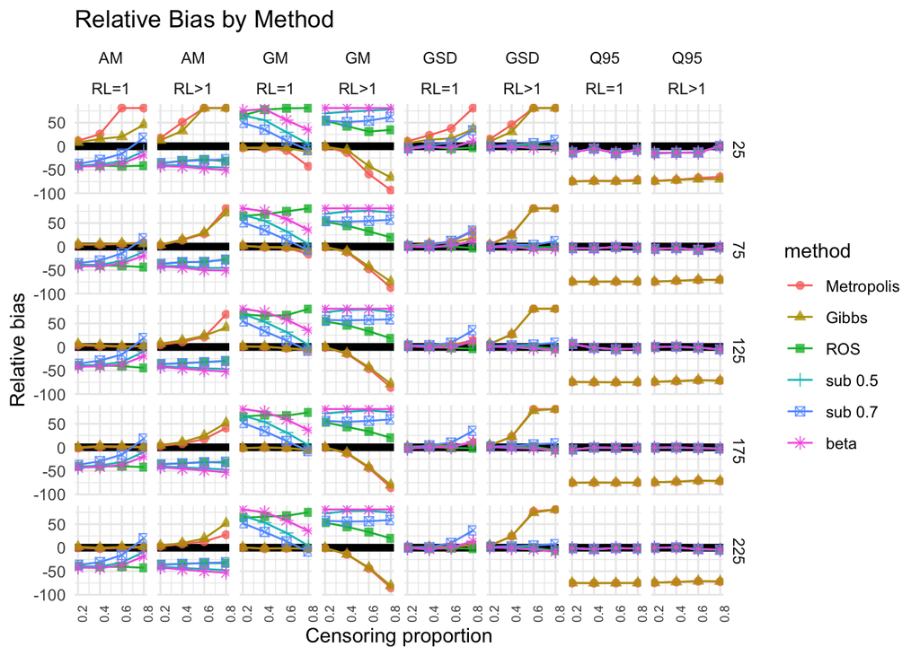

```r
# Relative bias
ggplot(performance1, aes(x = p, y = bias, color = method, shape = method)) +
  # Add y = 0 reference line
  geom_hline(yintercept = 0, linetype = "solid", color = "black", linewidth = 2) +
  geom_line() +
  geom_point(size = 2, alpha = 0.8) +
  facet_grid(n ~ param + single.rl, labeller = labeller(single.rl = label_value)) +
  theme_minimal() +
  labs(title = "Relative Bias by Method", x = "Censoring proportion", y = "Relative bias") +
  theme(
    axis.text.x = element_text(size = 7, angle = 90, hjust = 1)
  ) +
  expand_limits(y = -10)  # Ensure y=0 is in all facets
```

A similar analysis was performed for the **relative rMSE** of each method across estimands:

- **AM:**  
  Bayesian methods show smaller rMSE when there’s a single reporting limit. For multiple limits, rMSE increases sharply with censoring and can even exceed that of Frequentist methods.
- **GM:**  
  For both single and multiple limits, Bayesian methods have low rMSE at low censoring but it grows with censoring. Frequentist methods show a decrease in rMSE with increasing censoring under a single limit, likely due to imputation of a larger portion of data using low-variance constants, which reduces variability in estimates.
- **GSD:**  
  Under multiple limits, Bayesian methods show extremely large rMSEs. The flattening at high censoring is due to the 95% cap applied to make comparison feasible.
- **Q95:**  
  rMSE remains relatively stable across methods, but Frequentist methods consistently show much lower values, indicating better tail performance.

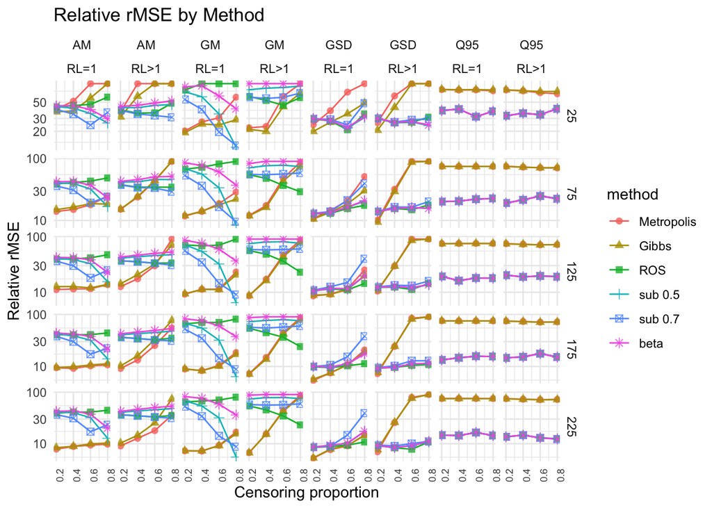

```r
# relative rMSE
ggplot(performance1, aes(x = p, y = rmse, color = method, shape = method)) +
  geom_line() +
  geom_point(size = 2, alpha = 0.8) +
  facet_grid(n ~ param + single.rl, scales = "free_y", labeller = labeller(single.rl = label_value)) +
  scale_y_continuous(trans = log_trans(base = 10)) +
  theme_minimal() +
  labs(title = "Relative rMSE by Method", x = "Censoring proportion", y = "Relative rMSE") +
  theme(
    axis.text.x = element_text(size = 7, angle = 90, hjust = 1)
  )
```

## 3.2 Two-element model

In the two-element model, the same estimands were computed for the sum of the two elements. We also check their relative bias and relative rMSE.

```r
# Compute performance measures
performance2 <- calculate_performance_measures(estimands2)
rl2 <- performance2$single.rl
performance2$single.rl[rl2] <- 'RL=1'
performance2$single.rl[!rl2] <- 'RL>1'
# There are extreme values in the bias and rmse
p2_sum <- summary(performance2)
#cap the extreme values to allow for better visualization.
performance2[performance2$bias > quantile(performance2$bias, 0.95), 'bias'] <-
  quantile(performance1$bias, 0.95)
# Do the same for rmse
performance2[performance2$rmse > quantile(performance2$rmse, 0.95), 'rmse'] <-
  quantile(performance2$rmse, 0.95)
```

The same type of plots were generated for relative bias and rMSE, but only the Gibbs sampler was used for the Bayesian method in this case.

Overall, no clear advantage of the Bayesian (Gibbs) method over Frequentist methods is observed — unlike in the single-element model.

Both Bayesian and Frequentist methods tend to overestimate AM and GM across all scenarios, with Bayesian methods showing higher positive bias for GM.

For GSD and Q95, the Bayesian method tends to underestimate, while Frequentist methods tend to overestimate.

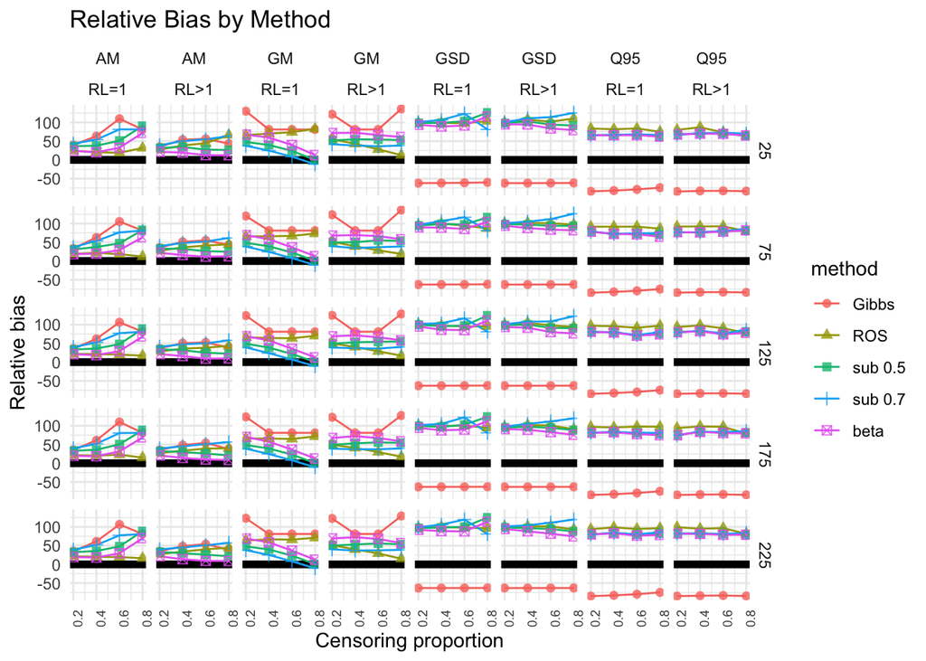

```r
# Relative bias
ggplot(performance2, aes(x = p, y = bias, color = method, shape = method)) +
  # Add y = 0 reference line
  geom_hline(yintercept = 0, linetype = "solid", color = "black", linewidth = 2) +
  geom_line() +
  geom_point(size = 2, alpha = 0.8) +
  facet_grid(n ~ param + single.rl, labeller = labeller(single.rl = label_value)) +
  theme_minimal() +
  labs(title = "Relative Bias by Method", x = "Censoring proportion", y = "Relative bias") +
  theme(
    axis.text.x = element_text(size = 7, angle = 90, hjust = 1)
  ) +
  expand_limits(y = -10)  # Ensure y=0 is in all facets
```

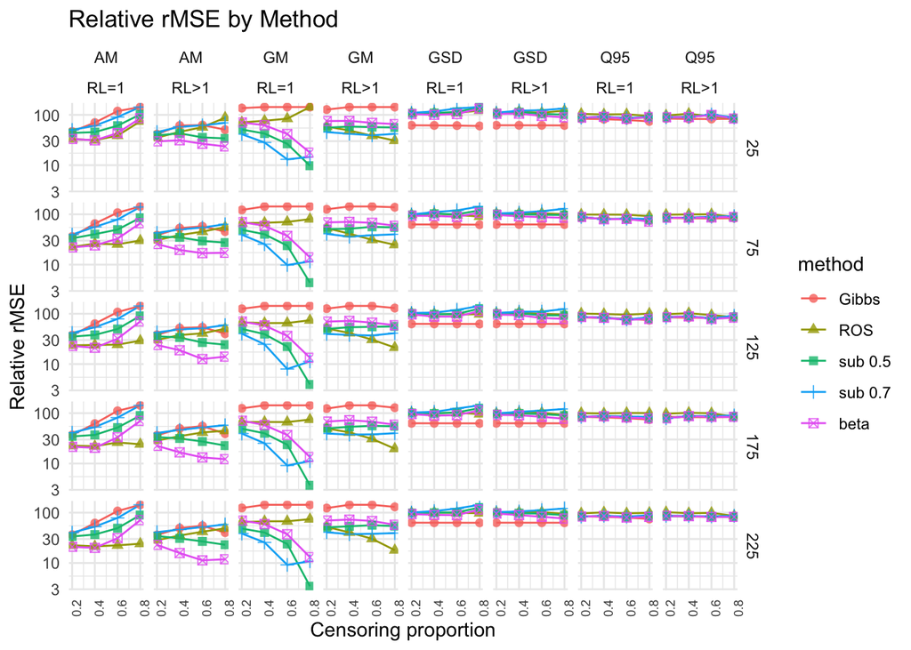

```r
# rMSE
ggplot(performance2, aes(x = p, y = rmse, color = method, shape = method)) +
  geom_line() +
  geom_point(size = 2, alpha = 0.8) +
  facet_grid(n ~ param + single.rl, labeller = labeller(single.rl = label_value)) +
  scale_y_continuous(trans = log_trans(base = 10)) +
  theme_minimal() +
  labs(title = "Relative rMSE by Method", x = "Censoring proportion", y = "Relative rMSE") +
  theme(
    axis.text.x = element_text(size = 7, angle = 90, hjust = 1)
  )
```

# 4 Conclusions

This project systematically compared Bayesian and Frequentist methods in estimating four key parameters (AM, GM, GSD, Q95) under varying conditions of sample size, censoring proportion, and reporting structure (single/multiple limit). Two models were considered: a single-element model and a more complex two-element model (with correlation).

## 4.1 Single-Element Model

**Advantage of Bayesian Methods**

- **AM and GM**:  
  Metropolis and Gibbs generally performed well under single reporting limit in terms of relative bias and rMSE, especially when the sample size was moderate or large and censoring was low to moderate. In contrast, Frequentist methods tended to underestimate AM and overestimate GM in the same settings.
- **GSD**:  
  Under single reporting limit, Metropolis and Gibbs showed performance comparable to Frequentist methods, with similar levels of relative bias and rMSE.

**Disadvantate of Bayesian Methods**

- **AM and GM**: Under multiple reporting limits, Metropolis and Gibbs performed reasonably under low censoring but became unstable with high censoring.
- **Q95**: Bayesian methods exhibited severe underestimation, while Frequentist methods were more robust in estimating tails.
- In terms of relative rMSE, Bayesian methods were efficient for low censoring, but deteriorated with higher censoring, especially under multiple reporting limits.

## 4.2 Two-Element Model

- Only the Gibbs sampler was used for Bayesian inference due to computational constraints.
- Neither method showed clear superiority: both Bayesian and Frequentist methods performed poorly, with high relative rMSE across all estimands.
- AM and GM were generally overestimated by both approaches, with Bayesian methods showing higher positive bias for GM.
- For GSD and Q95, Bayesian methods underestimated, while Frequentist methods overestimated, showing a consistent pattern of opposing bias directions.
- Overall, the performance gap between methods was minimal, suggesting the added complexity in the two-element model reduces the effectiveness of both frameworks.

## 4.3 Discussion and Future Directions

Bayesian methods, particularly the Gibbs sampler, offer greater modeling flexibility and tend to perform well under moderate complexity and low to moderate censoring levels. The Gibbs sampler is computationally efficient when proper priors are used and remains feasible even for complex models, like the two-element model, by employing Gibbs-within-Gibbs for data augmentation. However, this approach introduces bias due to the approximation in sampling from bivariate truncated normals. The bivariate Metropolis approach, on the other hand, can be computationally prohibitive unless joint likelihoods are efficiently computed or approximated.

Frequentist substitution methods, while simpler and computationally cheaper, often perform better for tail-related estimands like Q95 and GSD. However, these methods can introduce systematic bias when estimating AM and GM, largely due to their rigid imputation schemes that fail to account for uncertainty in censored values.

The choice between Bayesian and Frequentist methods depends on the specific **estimand** of interest, the **severity of censoring**, and the available **computational resources**. No method is universally optimal across all conditions.

The increased bias and relative mean square error (rMSE) observed in the two-element model highlight several areas for improvement, including enhancing model structure, refining data augmentation techniques, using more informative priors, and considering joint or hierarchical modeling to stabilize parameter estimates.

**Unresolved Questions**

While the study has provided valuable insights, several important questions remain to be addressed:

- **Performance Metrics:** The study uses relative bias and relative rMSE as performance measures. Are there other metrics (e.g., coverage probability) that could provide additional insights into model performance?
- **Impact of Data Distribution:** How would the results change if the data were generated from a different distribution or with alternative parameter values?
- **Estimand Selection:** The estimands chosen (GM, GSD, AM, Q95) reflect common choices for left-censored data. Are there other estimands (e.g., median, interquartile range) that might provide more relevant insights?
- **Dependency Structure in Frequentist Methods:** In the two-element model, Frequentist methods impute censored values separately, despite the correlation between elements. How might accounting for this dependency structure improve their performance?
- **Complexity of the Two-Element Model:** Both Bayesian and Frequentist methods show increased bias and rMSE in the two-element model. What aspects of the model’s complexity might contribute to this reduced performance?
- **Outliers and Extreme Values:** Some outliers were observed in the analysis. How do these extreme values influence model interpretation, and how can they be handled effectively in future analyses?
- **Correlation and Estimation:** How does the correlation between elements in the bivariate model affect the estimation of the sum of concentrations?
- **Monte Carlo Replications:** The study used 100 Monte Carlo replications to estimate performance measures. Is this optimal? How can we determine the appropriate number of replications for a robust estimate?

**Future research could focus on the following areas:**

- **Efficient Data Augmentation:** Developing improved data augmentation techniques, particularly for high-dimensional censoring, to better handle complex dependencies in censored data.
- **Metropolis Algorithm in Bivariate Models:** Exploring faster algorithms for the Metropolis method in bivariate or multivariate settings, to make them more computationally feasible.
- **Predictive Model Checking:** Implementing predictive model checking tools, such as posterior predictive p-values, to assess model fit and adequacy under varying levels of censoring and model complexity.

# 5 Appendix

## 5.1 True values of the estimands

**GM and GSD**

Geometric mean (GM) and standard deviation (GSD) describes the multiplicative properties of the data. For lognormal distributed data, there is a definitive mapping from the mean and standard deviation of the log-transformed data to GM and GSD (true value / at population level):
$$\text{GM} = \exp(\mathbb E[\log Y]) = \exp (\mu)$$
$$\text{GSD} = \exp\left(\sqrt{\mathbb E[(\log Y - E[\log Y])^2]}\right) =
\exp (\sigma)$$
if log-transformed data follows a normal distribution with parameters $(\mu, \sigma^2)$.

In our simulation studies, the true values GM and GSD are known univariate case as $(\mu, \sigma^2)$ are our design.

Whereas for the bivariate case, since our insterest is the sum of the two variables $Y_1, Y_2$, we know the true GM and GSD of $Y_1, Y_2$ separately as we know $(\mu_1, \mu_2, \sigma_1^2, \sigma_2^2, \rho)$ from our design. However, we don’t know the true GM and GSD of $Y_1 + Y_2$.

- $Y_1 + Y_2$ doesn’t have to follow a lognormal distribution. There is no closed form for its density.
- GM is computed from $\exp(\mathbb E[\log (Y_1 + Y_2)])$, which is non-trivial and not to mention we do not have the closed form of the density of $Y_1 + Y_2$ or $\log (Y_1 + Y_2)$.
- Same arguments hold for GSD
- We may be possible to obtain the closed form of the arithmetic mean (AM) and arithmetic standard deviation (ASD) for $Y_1 + Y_2$. If $Y_1 + Y_2$ is distributed as a lognormal, we can convert from AM and ASD to GM and GSD, but the sum of lognormals is not lognormal.

**AM**

Arithmetic mean describes the average property of the data and computed from (true value / at population level):
$$\text{AM} = \mathbb E[\bar Y] = \exp(\mu + \frac{\sigma^2}{2})$$
given our data is independently and identically distributed following lognormal with log mean $\mu$ and log sd $\sigma$.

From this, we know the true value of AM for the univariate case but also the bivariate case for the sum of $Y_1 + Y_2$, as our data is independently and identically distributed implying the summed data also i.i.d.

$$\text{AM}_2 = \mathbb E[\overline{(Y_1 + Y_2)}] = \mathbb E[\bar Y_1 +
\bar Y_2] = \exp(\mu_1 + \frac{\sigma^2_1}{2}) + \exp(\mu_2 +
\frac{\sigma^2_2}{2})$$

We can also have a look at the variance of the sum which we can also find closed form:

$$\text{Var}(Y_1 + Y_2) = \text{Var}(Y_1) + \text{Var}(Y_2) +
2\text{Cov}(Y_1, Y_2)$$

From the parameters of log-transformed data to the origional data space we have (GPT results):
$$\text{Var}(Y_i) = (\exp(\sigma^2_i) - 1) \times \exp(2\mu_i +
\sigma^2_i)$$
$$\text{Cov}(Y_1, Y_2) = \exp(\mu_1 + \mu_2 + \frac12(\sigma^2_1 +
\sigma^2_2)) \times (\exp(\rho\sigma_1\sigma_2) - 1)$$

With the above we can obtain the true value of the arithmetic standard deviation of $Y_1 + Y_2$. If we further assume $Y_1 + Y_2$ follows a lognormal, we can use the mapping (specific for lognormal) from arithmetic parameters to geometric parameters so as to obtain the true values of GM and GSD of $Y_1 + Y_2$. However, $Y_1 + Y_2$ is not certainly lognormal distributed.

**95% quantile**

We are also interested in the 95% quantile, which in the case of univariate is the 95% quantile of a lognormal, and the bivariate case is the quantile of the distribution of $Y_1 + Y_2$.

For univariate case, we can obtain the true value of this quantile from the known parameters of the lognormal, but for the bivariate case it’s again not possible due to we don’t have a closed form density for $Y_1 + Y_2$.

## 5.2 Sample analysis on MCMC convergence

### 5.2.1 Single-element model

**Metropolis**

*Choice of the prior:*

All the basic operations are on the log scale because it makes the MCMC algorithm numerically stable, especially for the acceptance ratio made of probabilities. If the latters have extremely small values, multiplication can lead to underflow for the computer, whereas log scale assures addition, which is numerically safer.

Working on the log scale is essential in MCMC because it makes the algorithm numerically stable, efficient, and compatible with how the acceptance rule is naturally expressed — in terms of log-posterior differences.

We have decided to keep the functions provided by the Professor in $ChatGPT1_students.r$ file. Having weak prior belief on $mu$, it makes sense to go for a weakly informative normal prior with mean 0 and standard deviation(SD) of 10. The latter allows uncertainty, but not extreme or unrealistic values. The value of 0 as mean reflects how weakly confident we are about the true value of $mu$.

Optimal proposal function:

This function has inputs one univariate left-censored data. It outputs optimal standard deviations (SD) for the proposal that will be used for $mu$ and $sigma$ in the Random Walk Metropolis algorithm. The goal is to achieve a target acceptance rate for the latter which will be performed after finding the optimal proposal SDs. A rate of 44% is chosen, because it’s an empirical sweet spot for univariate data. This allows to quickly have a good mixing in the real Metropolis, having its stationary properties preserved.

It starts with inital values for the mu and sigma. Log of the latters are taken to keep SDs positive.Usual Metropolis runs for this adaptive phase with an added step at each end of iteration, where we adapt the proposal SD based on the actual state of the acceptance rate. It uses the so-called Robbins-Monro rule:

log(SD)←log(SD)+γ0⋅(acceptance−target)

This increases (decreases) the SD if current acceptance rate was too high (too small). At the end of all iterations, it gives back the optimal proposal SDs for $mu$ and $sigma$, converted back from the log scale.Target acceptance rate is not necessarily reached because of finite number of iterations,but it is at least close to it.

Random Walk Metropolis algorithm:

The final function of the algorithm, for a given data and its optimal proposal SDs from previous function, outputs three post-burn-in(half) chains for $mu$ and $sigma$, started from different initial values. This allows us to compute convergence diagnostics like Gelman-Rubin R_hat and Effective Sample Size(ESS).

(I have modified the function, metropolis multi chain. I don’t combine the chains of mu and sigma so that I can plot them into on traceplot each, to emphasize convergence.)

Diagnostic for one single dataset

To have an example of convergence diagnostics, we took the following simulated left-censored data and applied our Metropolis algorithm on it:

n = 25 p = 0.2 single.rl = true

```r
data_list <- readRDS("single_element_data.rds")
# Extract index of a sample data-generating mechanism
grid_idx <- grid %>%
  filter(n == 25, p == 0.2, single.rl == TRUE) %>%
  dplyr::select(grid_idx) %>%
  as.numeric()
# Extract the dataset for the first replication
data_uni <- data_list[[1]]$data
# Run 3-chain metropolis
set.seed(318)
results <- metropolis1_multi_chain(data_uni)
```

Trace plot:

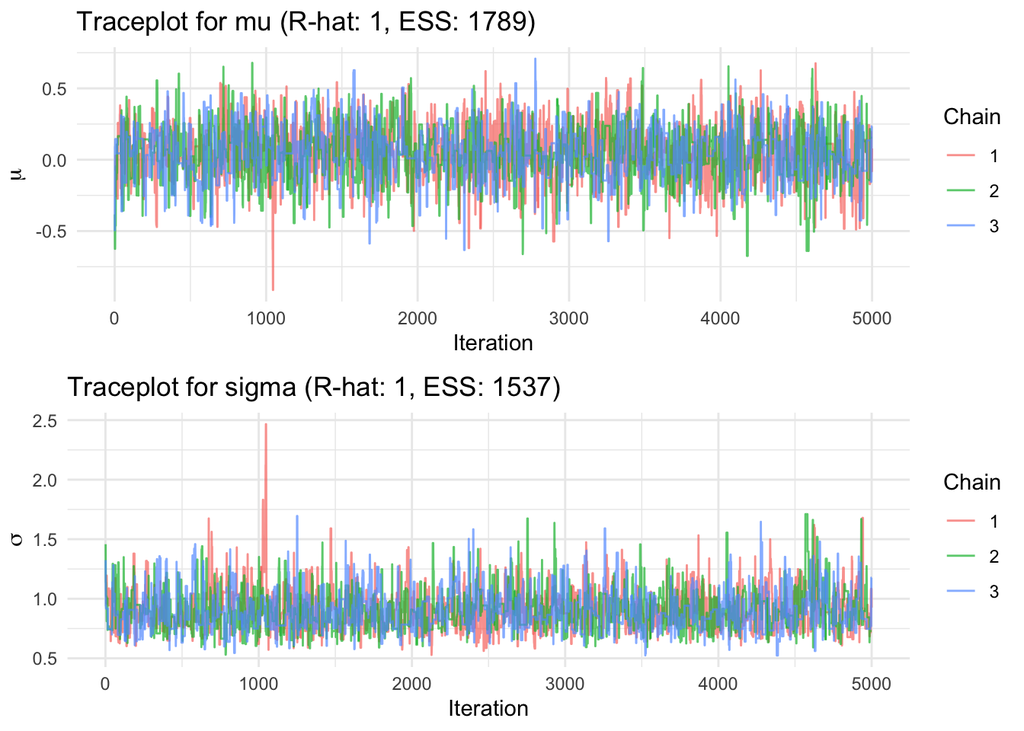

```r
# ChatGPT helped to build/debug this code:

posterior <- results$posterior
rhat <- results$rhat
ess <- results$ess

n_iter <- nrow(posterior) / 3

mu_chains <- split(posterior$mu, rep(1:3, each = n_iter))
sigma_chains <- split(posterior$sigma, rep(1:3, each = n_iter))

# Recreate data frames for plotting
mu_df <- data.frame(
  iter = rep(1:n_iter, times = 3),
  value = unlist(mu_chains),
  chain = factor(rep(1:3, each = n_iter)),
  param = "mu"
)

sigma_df <- data.frame(
  iter = rep(1:n_iter, times = 3),
  value = unlist(sigma_chains),
  chain = factor(rep(1:3, each = n_iter)),
  param = "sigma"
)

# Combine into one data frame
trace_data <- rbind(mu_df, sigma_df)

# Extract diagnostics
rhat_mu <- round(rhat[1, 1], 2)
rhat_sigma <- round(rhat[1, 2], 2)
ess_mu <- round(ess[1], 0)
ess_sigma <- round(ess[2], 0)

# Plot for mu
p_mu <- ggplot(subset(trace_data, param == "mu"), aes(x = iter, y = value, color = chain)) +
  geom_line(alpha = 0.7) +
  labs(
    title = paste0("Traceplot for mu (R-hat: ", rhat_mu, ", ESS: ", ess_mu, ")"),
    x = "Iteration", y = expression(mu), color = "Chain"
  ) +
  theme_minimal()

# Plot for sigma
p_sigma <- ggplot(subset(trace_data, param == "sigma"), aes(x = iter, y = value, color = chain)) +
  geom_line(alpha = 0.7) +
  labs(
    title = paste0("Traceplot for sigma (R-hat: ", rhat_sigma, ", ESS: ", ess_sigma, ")"),
    x = "Iteration", y = expression(sigma), color = "Chain"
  ) +
  theme_minimal()

# Show plots together
grid.arrange(p_mu, p_sigma, ncol = 1)
```

Above are the trace plots of the three post-burn-in chains of $mu$ and $sigma$ respectively. Next to the title is also the Gelman-Rubin R hat and the ESS when the three chains are combined(making a single chain of length 15’000).

First of all, the trace plots reflect an excellent mixing of the chains.They’re almost overlapping each other, forming this “fat caterpillars” pattern, reflecting their stationarity. Gelman Rubin R hats are a lot more smaller than 1.1, which are excellent. Then, ESS are high and they show that the autocorrelation between proposed values decreases quickly as the lag increases between them. This can be seen on the ACF plot.

ACF:

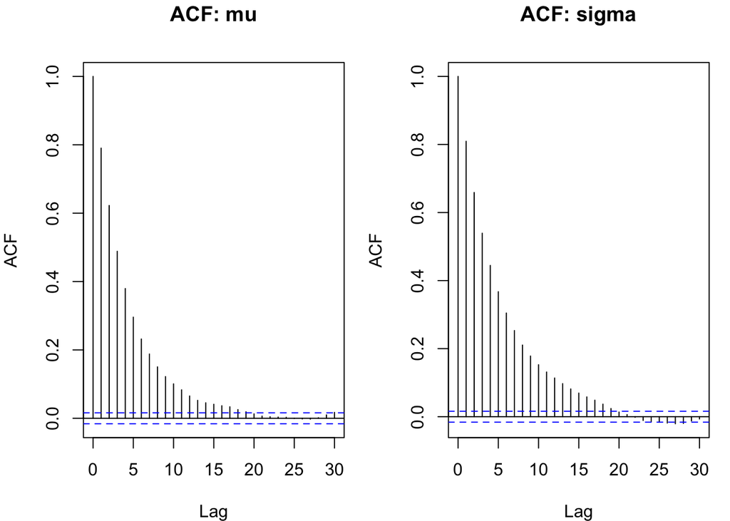

```r
combined_mu <- results$posterior$mu
combined_sigma <- results$posterior$sigma


op <- par(mfrow = c(1, 2), mar = c(4, 4, 3, 1))

# Plot ACF for mu
acf(combined_mu, lag.max = 30, main = "ACF: mu", cex.main = 1.4)

# Plot ACF for sigma
acf(combined_sigma, lag.max = 30, main = "ACF: sigma", cex.main = 1.4)
```

```r
par(op)
```

As said before, the correlation decreases quickly as the the lag increases, which aligns with the aim of a MCMC: mimicking “independent” samples with dependent ones.

# 6 Disclosure of AI use

*Lorena Coppola*

https://chatgpt.com/c/681ba946-1f90-8003-a98e-e722bb6eca8f

https://chatgpt.com/share/681ba744-b4a4-8003-aa54-7855e6a649cc

https://chatgpt.com/share/681bc704-2df8-8003-879a-6bfd43627f98

https://chatgpt.com/share/681bca18-dcec-8003-8bf9-6825b536f9f6

*Huimin Hu*

https://chatgpt.com/share/681875bc-2f68-800d-b8dc-75cb5f359f2d

https://chatgpt.com/share/6819f46d-0258-800d-bf32-8c88e8a40ff9

*Pooya Sabbagh Savoojbulagh*

https://chatgpt.com/share/681bcd40-6728-8006-bdc8-e83aacf1ea08

https://grok.com/share/bGVnYWN5_80274955-53e1-4a98-a550-58b6b0ba2e0d

https://grok.com/share/bGVnYWN5_b17e3267-d5f8-4471-bf2b-3a4565e7784e

*Akshaan Murugesu*

https://chatgpt.com/share/681ba1ff-dfac-8003-969c-f848c4a299c4

https://chatgpt.com/share/681ba276-1238-8003-b197-b6ca9ed0b009

*Paul Edward Schumacher*

https://chatgpt.com/share/681a8866-1044-800b-befa-811530d661ce